# hw-03

Yara Kanaan (S2729303)

2024-11-22

## Data load and preparation before modelling

```r
gss16<-read.csv("data/gss16.csv")
```

#### Cleaning and selecting columns

```r
gss16_advfront <- gss16 %>%
  select(advfront, emailhr, educ, polviews, wrkstat) %>%
  drop_na()
```

#### Re-levelling `advfront`

```r
gss16_advfront <- gss16_advfront %>%
  mutate(
    advfront = case_when(
      advfront == "Strongly agree" ~ "Agree",
      advfront == "Agree" ~ "Agree",
      TRUE ~ "Not agree"
    ),
    advfront = fct_relevel(advfront, "Not agree", "Agree")
  )
```

#### Re-levelling `polviews`

```r
gss16_advfront <- gss16_advfront %>%
  mutate(
    polviews = case_when(
      str_detect(polviews, "[Cc]onservative") ~ "Conservative",
      str_detect(polviews, "[Ll]iberal") ~ "Liberal",
      TRUE ~ polviews
    ),
    polviews = fct_relevel(polviews, "Conservative", "Moderate", "Liberal")
  )
```

#### Creating a new `fulltime` variable

```r
gss16_advfront <- gss16_advfront %>%
  mutate(fulltime = ifelse(wrkstat == "Working fulltime",TRUE,FALSE))
```

## Exercise 1: Create a linear regression model

#### Exercise 1 (a)

```r
linear_reg() %>%
  set_engine("lm") %>%
  fit(emailhr ~ educ + fulltime, data = gss16_advfront) %>%
  tidy()
```

```
## # A tibble: 3 × 5
##   term         estimate std.error statistic  p.value
##   <chr>           <dbl>     <dbl>     <dbl>    <dbl>
## 1 (Intercept)    -3.35      1.61      -2.08 3.80e- 2
## 2 educ            0.538     0.114      4.73 2.55e- 6
## 3 fulltimeTRUE    5.28      0.624      8.46 7.69e-17
```

On average, individuals who are employed full - time spend 5.2796 more hours per week on email than individuals who are not employed full-time, this is assuming that all else is held constant

#### Exercise 1 (b)

```r
model <- lm(emailhr ~ educ + fulltime, data = gss16_advfront)

summary(model)
```

```
##
## Call:
## lm(formula = emailhr ~ educ + fulltime, data = gss16_advfront)
##
## Residuals:
##     Min      1Q  Median      3Q     Max
## -12.680  -5.715  -2.890   1.083  80.546
##
## Coefficients:
##              Estimate Std. Error t value Pr(>|t|)
## (Intercept)   -3.3516     1.6136  -2.077    0.038 *
## educ           0.5376     0.1137   4.728 2.55e-06 ***
## fulltimeTRUE   5.2796     0.6238   8.463  < 2e-16 ***
## ---
## Signif. codes:  0 '***' 0.001 '**' 0.01 '*' 0.05 '.' 0.1 ' ' 1
##
## Residual standard error: 10.55 on 1169 degrees of freedom
## Multiple R-squared:  0.08517,    Adjusted R-squared:  0.08361
## F-statistic: 54.42 on 2 and 1169 DF,  p-value: < 2.2e-16
```

```r
glance(model)
```

```
## # A tibble: 1 × 12
##   r.squared adj.r.squared sigma statistic  p.value    df logLik   AIC   BIC
##       <dbl>         <dbl> <dbl>     <dbl>    <dbl> <dbl>  <dbl> <dbl> <dbl>
## 1    0.0852        0.0836  10.6      54.4 2.53e-23     2 -4423. 8854. 8874.
## # ℹ 3 more variables: deviance <dbl>, df.residual <int>, nobs <int>
```

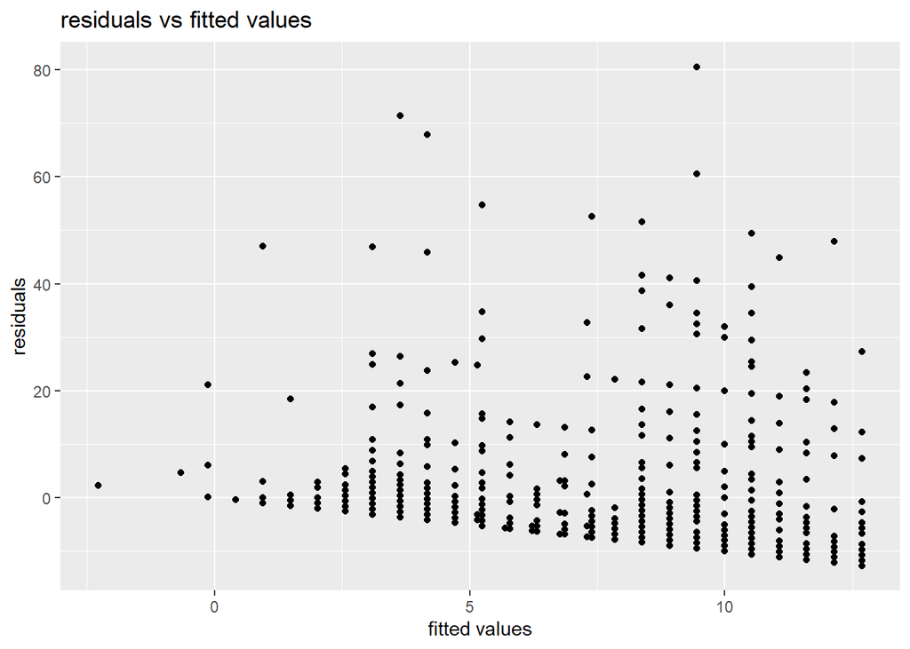

```r
# plotting residuals vs fitted values

ggplot(data = model, aes(x = .fitted, y = .resid)) +
  geom_point() +
  labs(x = "fitted values", y = "residuals") +
  ggtitle("residuals vs fitted values")
```

One of the assumptions of linear regression is that the variance of the residuals should be constant. To check this, I did a residuals vs fitted values plot. Once I plotted this, I saw a cone shaped pattern, suggesting that the variance is not constant, meaning the residuals spread increases as the fitted values increase - this means the variance is not constant so, the assumption is incorrect and the model is invalid/ not reliable.

The r squared value is very low (much closer to 0 than to 1), meaning that the model cannot validly be used to predict anything. this is because since the low r squared and adjusted r squared value is very low. This indicates a low correlation between the variables (educ and fulltime)

## Exercise 2: Create a workflow to fit a model

```r
set.seed(1234)
gss16_split <- initial_split(gss16_advfront)
gss16_train <- training(gss16_split)
gss16_test  <- testing(gss16_split)
```

#### Exercise 2 (a)

```r
gss16_rec_1 <- recipe(advfront ~ educ, data = gss16_train) %>%
  step_dummy(all_nominal(), -all_outcomes())

gss16_mod_1 <- logistic_reg() %>%
  set_engine("glm")


# creating the workflow

gss16_wflow_1 <- workflow() %>%
  add_recipe(gss16_rec_1) %>%
  add_model(gss16_mod_1)
```

#### Exercise 2 (b)

I picked a logistic regression because it models the probability of something happening, requiring the response variable to be binary - in this case the response variables are in agreement or not in agreement. Since logistic regression is designed for situations like these, I thought it would be the perfect model for this.

#### Exercise 2 (c)

```r
gss16_fit_1 <- gss16_wflow_1 %>%
  fit(data = gss16_train)


gss16_fit_1 %>%
  extract_fit_parsnip() %>%
  tidy()
```

```
## # A tibble: 2 × 5
##   term        estimate std.error statistic   p.value
##   <chr>          <dbl>     <dbl>     <dbl>     <dbl>
## 1 (Intercept)   -0.375    0.485     -0.773 0.439
## 2 educ           0.150    0.0356     4.21  0.0000252
```

## Exercise 3: Logistic regression with single predictor

#### Exercise 3 (a)

```r
library(pROC)
```

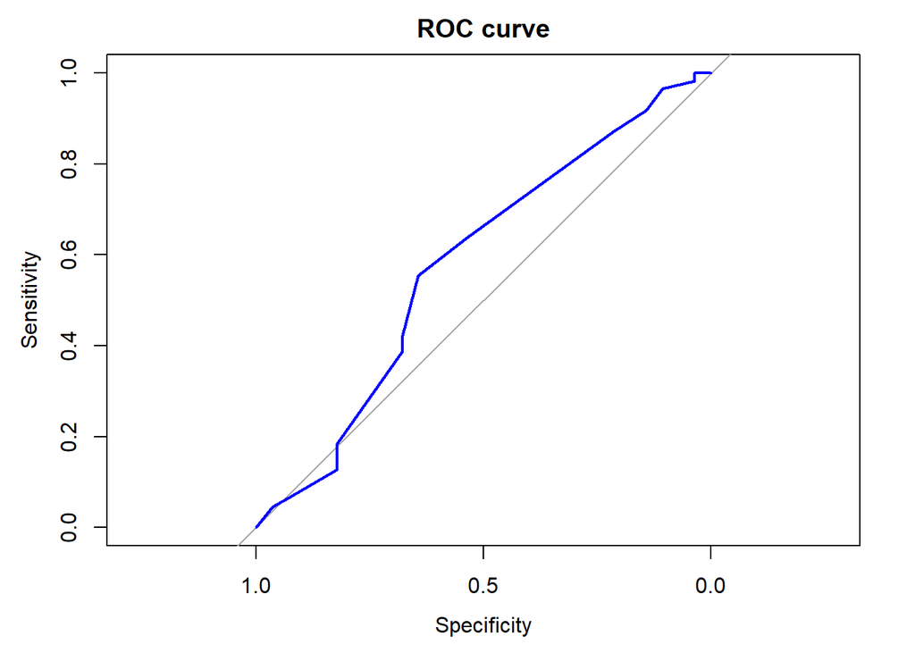

```r
gss16_pred_1 <- predict(gss16_fit_1, new_data = gss16_test, type = "prob")

true_values <- gss16_test$advfront

roc_curve <- roc(true_values, gss16_pred_1$.pred_Agree)
plot(roc_curve, main = "ROC curve", col = "blue")
```

```r
# area under curve:
auc(roc_curve)
```

```
## Area under the curve: 0.5807
```

```r
ifelse(gss16_pred_1$.pred_Agree >= 0.85, "Agree", "Not agree")
```

```
##   [1] "Not agree" "Not agree" "Not agree" "Not agree" "Agree"     "Agree"
##   [7] "Agree"     "Agree"     "Not agree" "Not agree" "Agree"     "Agree"
##  [13] "Agree"     "Agree"     "Not agree" "Not agree" "Not agree" "Not agree"
##  [19] "Not agree" "Not agree" "Not agree" "Not agree" "Agree"     "Agree"
##  [25] "Not agree" "Agree"     "Agree"     "Agree"     "Not agree" "Not agree"
##  [31] "Not agree" "Agree"     "Agree"     "Agree"     "Agree"     "Not agree"
##  [37] "Agree"     "Agree"     "Not agree" "Agree"     "Not agree" "Agree"
##  [43] "Not agree" "Not agree" "Agree"     "Agree"     "Agree"     "Agree"
##  [49] "Not agree" "Not agree" "Agree"     "Agree"     "Not agree" "Agree"
##  [55] "Agree"     "Not agree" "Not agree" "Agree"     "Not agree" "Agree"
##  [61] "Agree"     "Not agree" "Not agree" "Not agree" "Not agree" "Not agree"
##  [67] "Not agree" "Not agree" "Agree"     "Not agree" "Not agree" "Agree"
##  [73] "Agree"     "Not agree" "Agree"     "Agree"     "Not agree" "Agree"
##  [79] "Not agree" "Not agree" "Agree"     "Not agree" "Not agree" "Not agree"
##  [85] "Not agree" "Not agree" "Not agree" "Not agree" "Not agree" "Agree"
```

[output cut: 34 more lines]

```r
# this means is the predicted probability for agree is greater than or same as 0.85 than we predict agree. if it is less than 0.85 we predict not agree
```

#### Exercise 3 (b)

```r
gss16_pred_binary <- ifelse(gss16_pred_1$.pred_Agree >= 0.85, "Agree", "Not agree")


true_values <- gss16_test$advfront

 # if actual value is agree and predicted value is agree than I assigned it YY
ifelse(true_values == "Agree" & gss16_pred_binary == "Agree", "YY",
 # if actual value is agree and predicted value is not agree than I assigned it YN
ifelse(true_values == "Agree" & gss16_pred_binary == "Not agree", "YN",
 # if actual value is not agree and predicted value is agree than I assigned it NY and NN
ifelse(true_values == "Not agree" & gss16_pred_binary == "Agree", "NN", "NY")))
```

```
##   [1] "YN" "YN" "YN" "YN" "YY" "YY" "YY" "YY" "YN" "NY" "YY" "YY" "YY" "YY" "YN"
##  [16] "YN" "YN" "YN" "YN" "YN" "YN" "YN" "YY" "YY" "YN" "YY" "YY" "YY" "YN" "YN"
##  [31] "YN" "YY" "YY" "YY" "YY" "YN" "YY" "YY" "YN" "NN" "YN" "YY" "NY" "NY" "YY"
##  [46] "YY" "YY" "NN" "YN" "YN" "YY" "NN" "YN" "YY" "YY" "YN" "YN" "YY" "YN" "YY"
##  [61] "YY" "YN" "YN" "YN" "YN" "YN" "NY" "YN" "YY" "NY" "YN" "YY" "YY" "NY" "YY"
##  [76] "YY" "YN" "YY" "YN" "YN" "YY" "YN" "NY" "YN" "YN" "YN" "YN" "YN" "YN" "YY"
##  [91] "YN" "YY" "YY" "YN" "YY" "YN" "YY" "YN" "YN" "YY" "YN" "YN" "YY" "YN" "YN"
## [106] "YY" "YN" "YY" "YN" "YY" "YY" "YY" "YY" "YY" "YY" "YY" "YY" "YN" "YN" "YY"
## [121] "YN" "YN" "YY" "YN" "YN" "NY" "YN" "YY" "YN" "YN" "YN" "YY" "YY" "YN" "YN"
## [136] "NY" "YY" "NN" "YN" "YN" "YN" "YN" "YY" "YY" "YN" "YN" "YN" "YY" "YN" "YY"
## [151] "YN" "YN" "YN" "YY" "YN" "YN" "YY" "YN" "YY" "YY" "YN" "NY" "YN" "YN" "YN"
## [166] "YY" "YY" "YY" "YN" "YY" "YN" "YN" "YN" "YY" "YN" "YN" "YN" "YY" "YN" "YY"
## [181] "YN" "YN" "YY" "YY" "YY" "YY" "NN" "YY" "YY" "YN" "YN" "YY" "YY" "NY" "NY"
## [196] "YY" "YN" "YN" "YN" "NY" "YY" "YY" "YN" "YN" "YY" "YY" "YY" "YN" "YY" "YN"
## [211] "NY" "YN" "YN" "YN" "NY" "YN" "NN" "YN" "YN" "NY" "YN" "YY" "YN" "YN" "YN"
## [226] "YN" "YN" "YN" "NN" "YY" "YN" "YN" "YN" "YY" "YY" "NN" "NY" "YN" "YN" "NY"
## [241] "YN" "YY" "YY" "YN" "YY" "YN" "YN" "YY" "YY" "YY" "YN" "YN" "YY" "YN" "YN"
## [256] "YN" "YY" "YN" "YN" "YN" "YN" "YN" "YN" "YY" "YN" "YN" "YN" "YY" "YN" "YN"
## [271] "YY" "YY" "YN" "YN" "YN" "YY" "YY" "YY" "YN" "YY" "NN" "YN" "YN" "NY" "YN"
## [286] "YN" "YN" "YN" "YN" "YY" "YY" "YN" "YY"
```

```r
YY <- sum(true_values == "Agree" & gss16_pred_binary == "Agree")
YN <- sum(true_values == "Agree" & gss16_pred_binary == "Not agree")
NN <- sum(true_values == "Not agree" & gss16_pred_binary == "Not agree")
NY <- sum(true_values == "Not agree" & gss16_pred_binary == "Agree")

# formula for sensititivity
sensitivity <- YY / (YY + YN)

# formula for specitivity
specificity <- NN / (NN + NY)

print(paste("Sensitivity: ", sensitivity))
```

```
## [1] "Sensitivity:  0.422641509433962"
```

```r
print(paste("Specificity: ", specificity))
```

```
## [1] "Specificity:  0.678571428571429"
```

## Exercise 4: Logistic regression modelling and interpretation

#### Exercise 4 (a)

```r
gss16_rec_2 <- recipe(advfront ~ polviews + wrkstat + educ, data = gss16_train) %>%
  step_dummy(all_nominal(), -all_outcomes())

gss16_mod_2 <- logistic_reg() %>%
  set_engine("glm")

# create the workflow
gss16_wflow_2 <- workflow() %>%
  add_recipe(gss16_rec_2) %>%
  add_model(gss16_mod_2)


# I will use logistic regression since we are predicting the advfront variable which is binary
```

#### Exercise 4 (b)

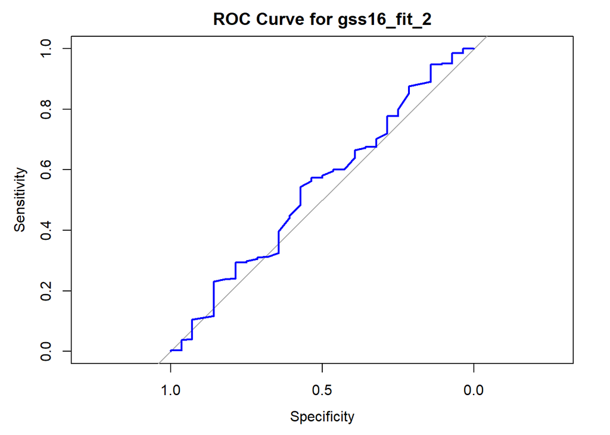

```r
#repeating previous code because it was not working otherwise

gss16_rec_2 <- recipe(advfront ~ polviews + wrkstat + educ, data = gss16_train) %>%
  step_dummy(all_nominal(), -all_outcomes())

gss16_mod_2 <- logistic_reg() %>%
  set_engine("glm")

# create the workflow
gss16_wflow_2 <- workflow() %>%
  add_recipe(gss16_rec_2) %>%
  add_model(gss16_mod_2)

#exercise answer

gss16_fit_2 <- fit(gss16_wflow_2, data = gss16_train)

gss16_preds <- predict(gss16_fit_2, new_data = gss16_test, type = "prob")

roc_curve <- roc(gss16_test$advfront, gss16_preds$.pred_Agree)
plot(roc_curve, main = "ROC Curve for gss16_fit_2", col = "blue")
```

```r
auc(roc_curve)
```

```
## Area under the curve: 0.5391
```

#### Exercise 4 (c)

AUC comparison: AUC of mode 1: 0.5807 AUC of model 2: 0.5391 When AUC is closer to 1, the model shows strong ability to distinguish between classes therefore the better model based on the AUC value is model 1 because 0.5807>0.5391

number of variables: model 1 has less variables than model 2. More variables usually means it is better at distinguishing between the two classes since it is provided with more information. This, however, is not always the case, especially when it comes to adding irrelevant variables. In model 2, i would say adding political views and work status could provide more relevant information and could help determine between the two classes with more confidence.

In conclusion, model 1 is better at distinguishing between the two variables overall, considering what I took into account. However it is not a clear difference since they both are so similar and there is not a very obvious distinguishing factor that makes one better than the other (have similar shapes, AUC values…)